# Selection Bias in SDM

2015-09-10

## a note on using this presentation

- press 'p' to see a note with a brief explanation for each slide
- press 'f' to see the presentation in 'full screen' mode

## the ideal world

### Representative sample

- systematic / random
- for species mapping: planned surveys

## the real world

### convenience sample

- geographically unrepresentative
- environmentally unrepresentative
- selection bias

## Selection bias

### any harm done?

- problem: where to select background/pseudo-absences?
- risk: to model sampling effort, not ecology
- questions: does it always matter (when)?

## Selection bias

### how to fix it

- bias-correction grid
- sub-sample (spatial filter)
- restrict background to part of area
- select in environmental space
- stratify domain and fit different models

## Concrete case study

### Kramer-Schadt et al. (2013)

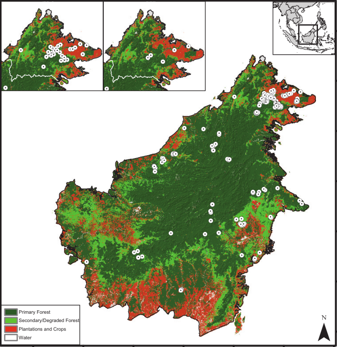

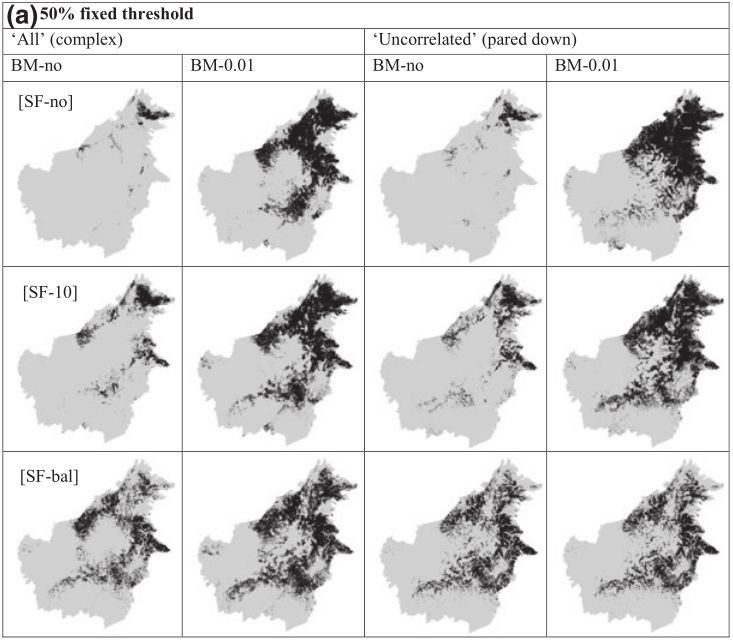

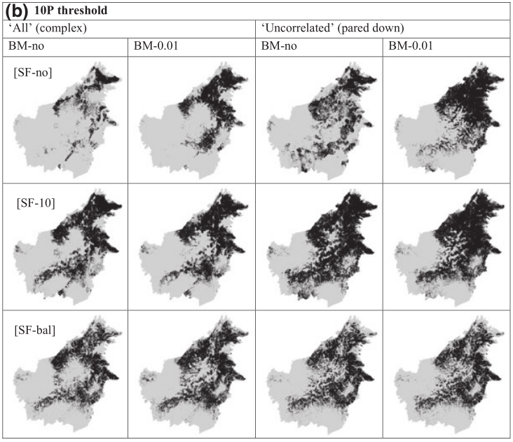

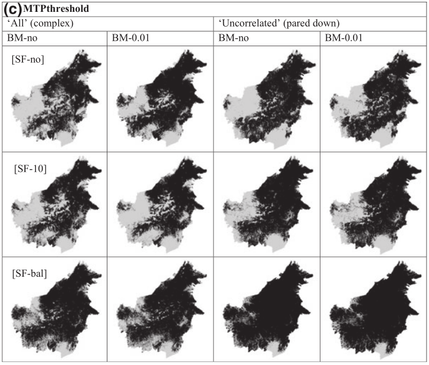

## Conclusions on bias correction

### Kramer-Schadt et al. 2013

- effects of bias-correction are large
- spatial filtering works best, followed by correction grid

## Another case

### Syfert, Smith, and Coomes (2013)

- Tree ferns, New Zealand
- real data (2 data sets!)
- external data for validation
- correction grid

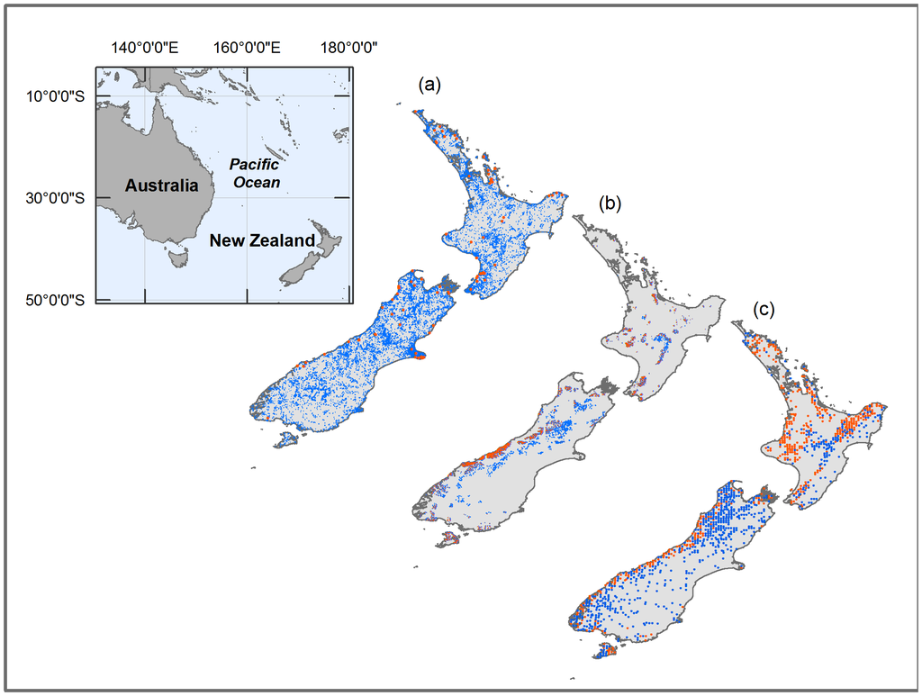

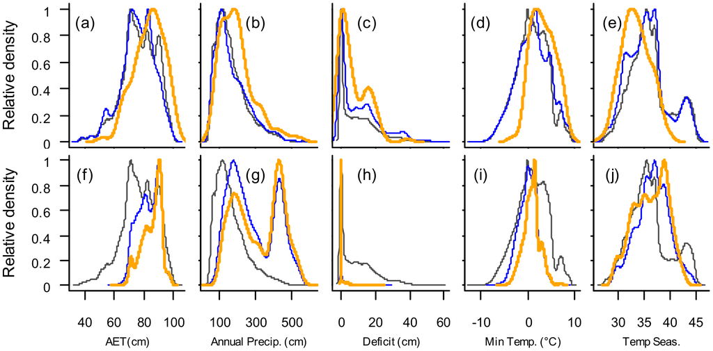

- orange - background on basis of tree ferns
- blue - background on basis of vascular plants
- black - all NZ locatoins (1 km resolution)

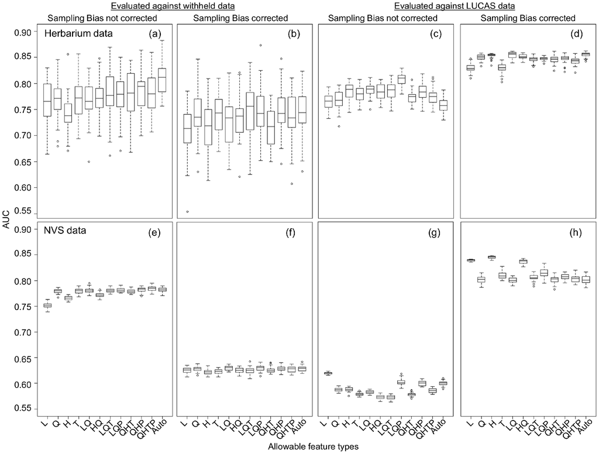

## Conclusions on bias correction

### [Syfert et al. 2013](http://dx.doi.org/10.1371/journal.pone.0055158)

- correction grid works well
- effects are large
- take care when evaluting 'bias-corrected models' on 'not bias-corrected data'

## Last case

### Fourcade et al. (2014)

- turtle & salamander data (2 species) & one virtual species
- different bias types, varying in degrees
- 5 bias correction methods
- AUC and 3 measures of overlap

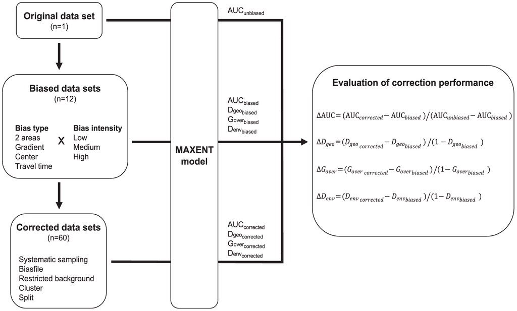

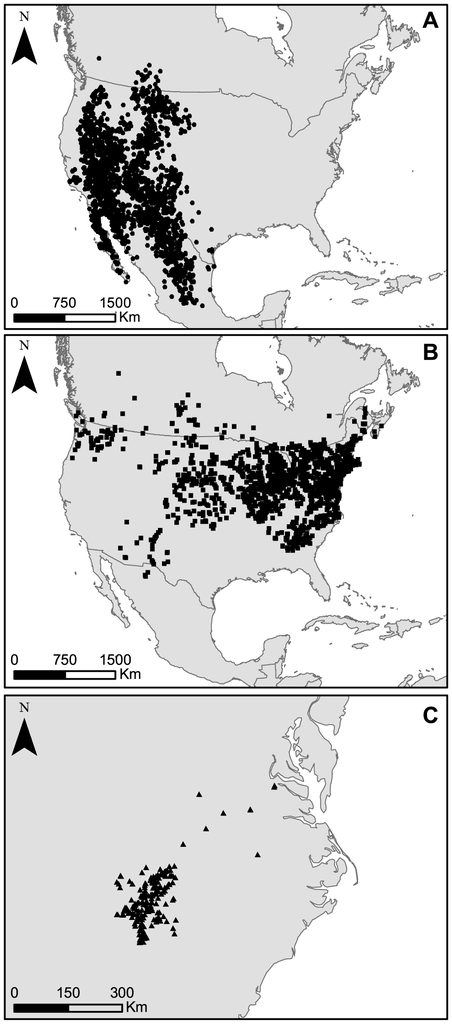

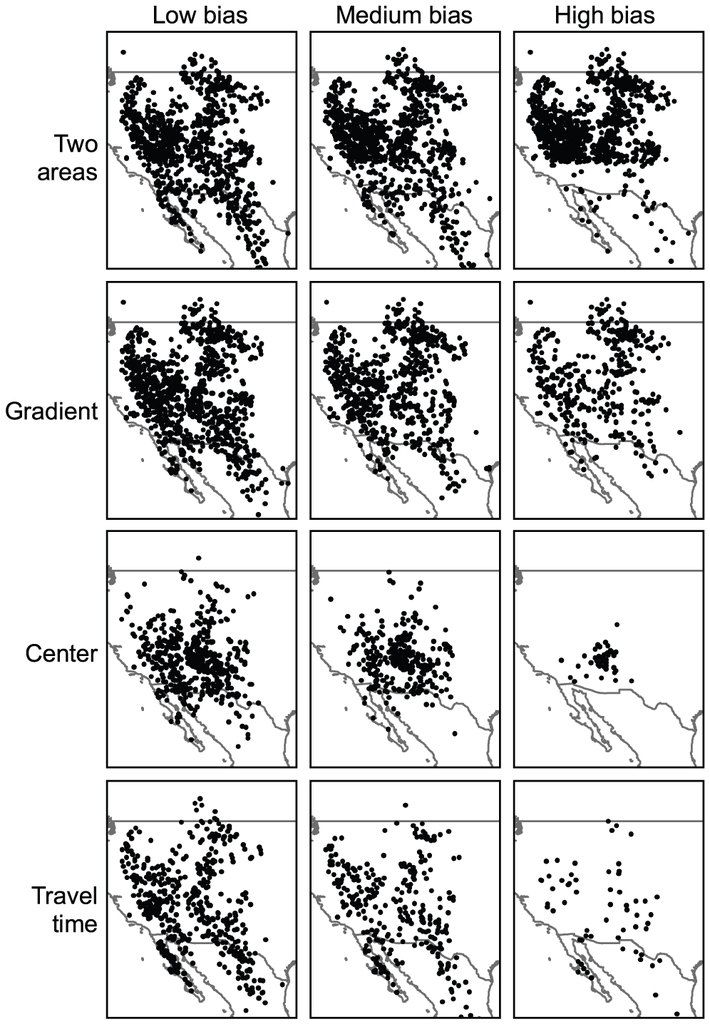

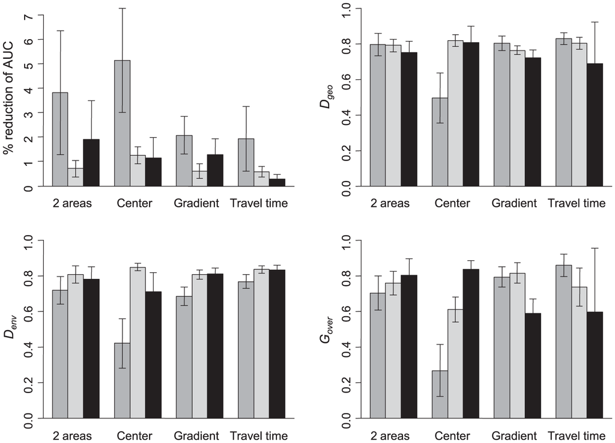

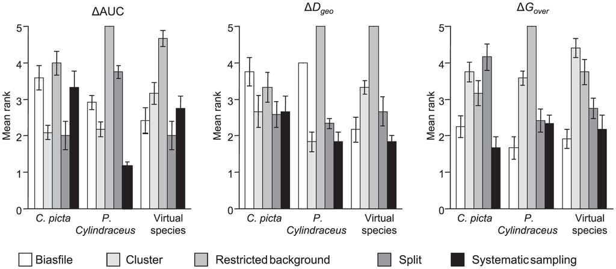

## Conclusions on bias correction

### [Fourcade et al. 2014](http://dx.doi.org/10.1371/journal.pone.0097122)

- sub-sampling worked best for different species & bias type
- effects are large but differ per error metric

## Overall conclusion

- so … do correct selection bias with:
  - sub-sample
  - correction grid

## Discussion points & questions

- nothing more practical than a good theory, … but can we build it?
- will more case studies help?
- how could [ZOÖN](https://github.com/zoonproject/zoon) help?

## References

Fourcade, Yoan, Jan O. Engler, Dennis Rödder, and Jean Secondi. 2014. “Mapping Species Distributions with MAXENT Using a Geographically Biased Sample of Presence Data: A Performance Assessment of Methods for Correcting Sampling Bias.” *PLoS ONE* 9 (5). Public Library of Science: e97122. doi:10.1371/journal.pone.0097122.

Kramer-Schadt, Stephanie, Jürgen Niedballa, John D. Pilgrim, Boris Schröder, Jana Lindenborn, Vanessa Reinfelder, Milena Stillfried, et al. 2013. “The Importance of Correcting for Sampling Bias in MaxEnt Species Distribution Models.” *Diversity and Distributions* 19 (11): 1366–79. doi:10.1111/ddi.12096.

Syfert, Mindy M., Matthew J. Smith, and David A. Coomes. 2013. “The Effects of Sampling Bias and Model Complexity on the Predictive Performance of MaxEnt Species Distribution Models.” *PLoS ONE* 8 (2). Public Library of Science: e55158. doi:10.1371/journal.pone.0055158.